# Abalone stress calculations

Mikaela Provost, Brock Woodson, Giulio De Leo, Fiorenza Micheli

12/09/2020

## Method 1: short-term variability

This method assumes that organisms experience thermal stress when temperature they experience differs from the temperature they are acclimatized to. Daily thermal stress increases when the difference between experienced and expected temperature increases. Using a moving window of 4 days, we fit a weighted linear regression using daily temperature, and use this to estimate the ‘acclimatized’ temperature for each day. This method is published in Dowd and Denny (2020).

In the time series plots below, color represents temperature abalone experienced above the site-specific thermal threshold (site-specific thermal limits are explained below). Units on the color bars is deg C.

Total stress per site is the integral of the absolute values of daily stress (Fig 1b). We standardize each integral value by dividing it by the number of days at each site. The units of the standardized integral values are (deg C*day)/day –> deg C day.

Dowd, W. W., & Denny, M. W. (2020). A series of unfortunate events: characterizing the contingent nature of physiological extremes using long-term environmental records. Proceedings of the Royal Society B, 287(1918), 20192333.

### Fig 1a) Daily temperatures

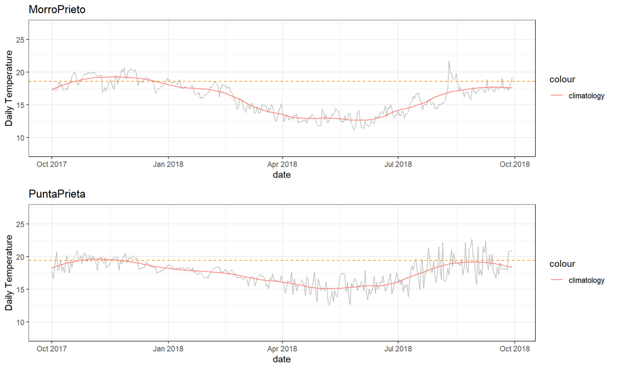

### Fig 1b) Daily stress values

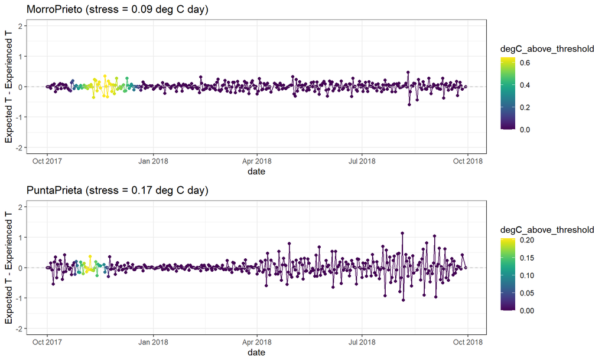

## Method 2: degree-heating days

Method 2 assumes that stress accumulates when abalone experience temperatures above an upper thermal limit. We assume there is some local adaptation among sites such that extreme temperatures experienced at one site may not be considered extreme, and therefore stressful, at another site. We define site-specific upper thermal limits as one standard deviation above the long-term mean of temperatures observed at that site. This method is published in Boch et al. (2018).

Instead of using daily temperature, we use each site’s climatology to examine stress experienced above the upper thermal limit. Climatology is calculated using the loess function in R with a 90 day smoothing window. In the time series plots below, daily temperture (grey line), climatology (red line), and upper thermal limit (orange dashed line) are plotted for each site.

Total stress at each site is the integral of temperatures greater than the site-specific thermal limit (deg C day). Just as in method 1, we then standaridze the integrals by the number of days in time series per site. Units of standardized integral values are deg C day.

Boch, C. A., Micheli, F., AlNajjar, M., Monismith, S. G., Beers, J. M., Bonilla, J. C., … & Woodson, C. B. (2018). Local oceanographic variability influences the performance of juvenile abalone under climate change. Scientific reports, 8(1), 1-12.

### Fig 2a) Climatology & temperature threshold

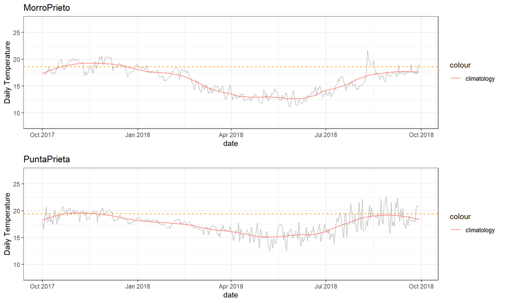

### Fig 2b) Daily stress values

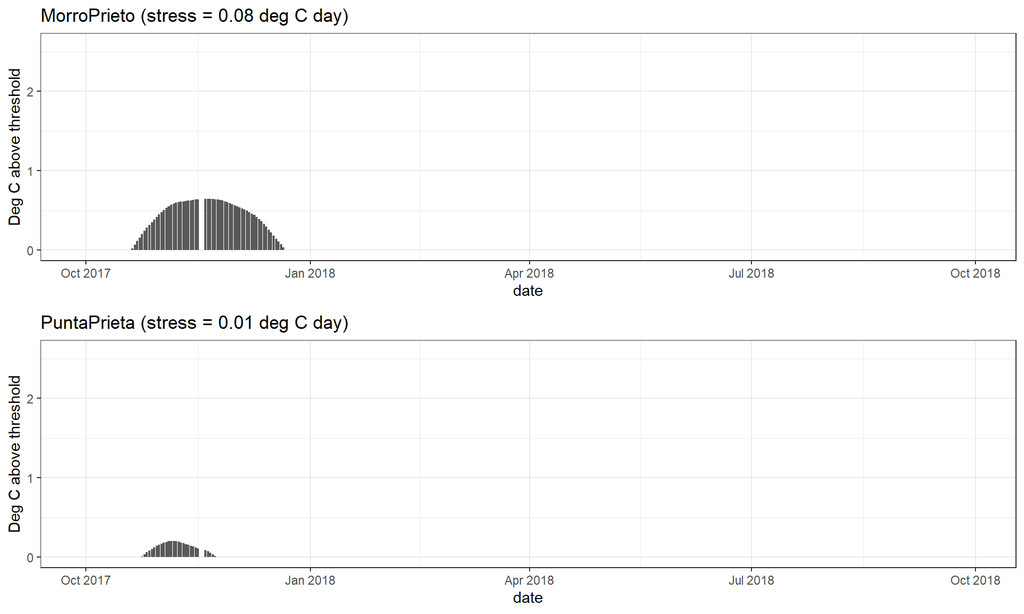

## Method 3: (climatology of potential max temp) - (short-term variability)

The goal of this method is to combine stress of thermal limits and stress associated with short-term variation in temperature. Short-term variability can be considered ‘good’ if temperatures are high because the variation in temperature has a cooling off effect. But there is still some stress associated with rapidly changing temps.

- In this menthod we calculate the potential maximum climatology. Climatology of the maximum values over a moving window.
- Then, we integrate the maximum climatology values above the site-specific thermal threshold. And standardize this integral by the number of days in temperature time series.
- Short-term variability is considered ‘good’ in this case and therefore reducing stress, so we subtract the amount of short-term variability stress as calculated in method 1 from the standardized integrals.

### Fig 3a) (max climatology) - (short-term variability stress)

Variability is a good thing when temperature is high. Abalone are ‘cooled off’.

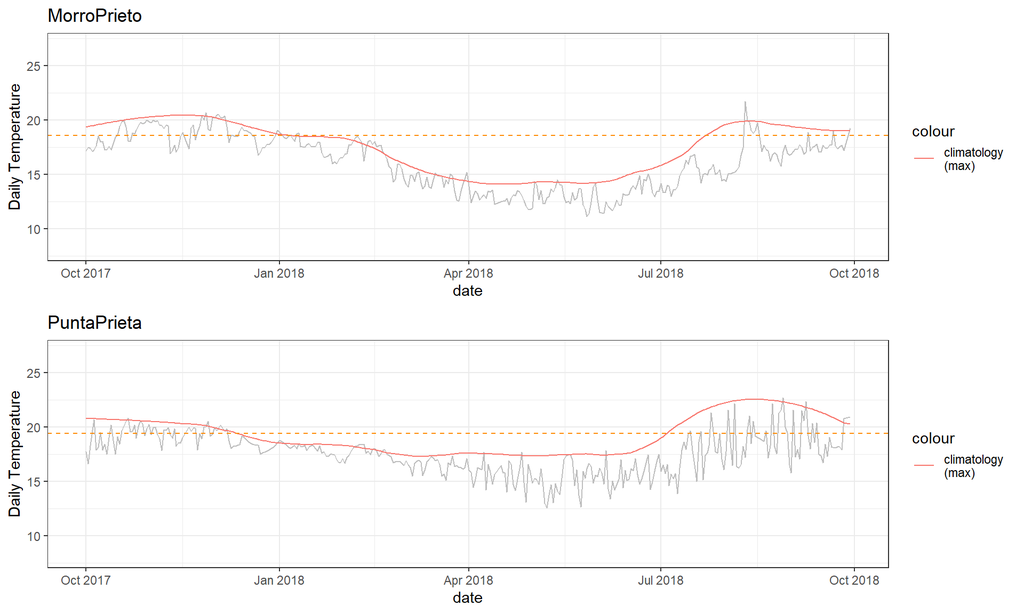

### Fig 3b) Daily stress values

Stress = (deg C of max climatology above threshold) - (stress due to short-term variability)

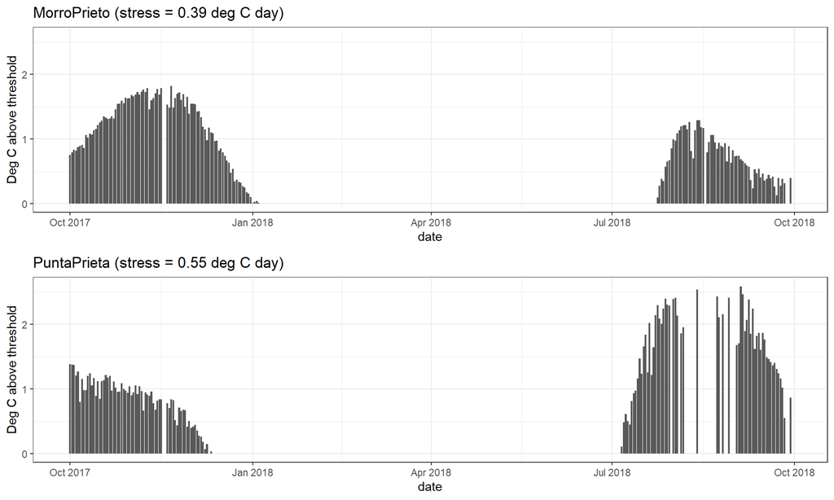

### Comparing 3 stress values

- Method 1: Short-term variability
- Method 2: Cumulative temp of mean climatology above thermal threshold
- Method 3: (max climatology) - (short-term variability)

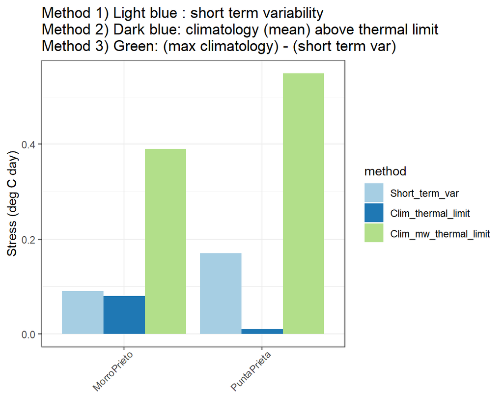

## Method 4: Thermal performance curve

We assume abalone operate under a specific thermal performance curve with a thermal limit (Tmax). The thermal response curve is adapted from Barneche et al 2014. The optimal temperature is set to the mean of the data from a site. We then normalize and invert the thermal performance curve so that the stress factor is zero at the optimal temperature and one above Tmax. Then to calculate stress, the difference between the optimal temperature and the temperature at each time is multiplied by the stress factor. We then take the absolute value and integrate to get an overall stress in deg C days.

Barneche, D. R., Kulbicki, M., Floeter, S. R., Friedlander, A. M., Maina, J., & Allen, A. P. (2014). Scaling metabolism from individuals to reef‐fish communities at broad spatial scales. Ecology Letters, 17(9), 1067-1076.